# EDA

EDA Matheus Leal 06 de outubro de 2019

Foi feita uma análise exploratória dos dados sobre o desempenho dos alunos da disciplina Laboratório de Programação II do Curso de Ciência da Computação da UFCG. São 441 observações, que se distribuem em 5 períodos letivos (2017.1 - 2019.1). Como cada período possuía um método de avaliação diferente, alguns com diferenças sutis, outros com diferenças mais expressivas, foi necessário, em determinados momentos, dividir nossa análise por período.

##Desempenho

O primeiro passo tomado foi analisar o desempenho das turmas nesses períodos para identificar discrepâncias e enxergar padrões.

Consideramos nossa primeira medida a média parcial. Ela nos dá um overview do desempenho das turmas, pois considera todas a avaliações excluindo a avaliação final.

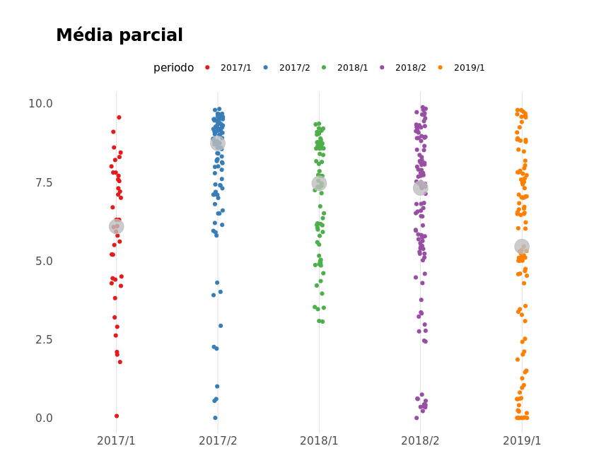

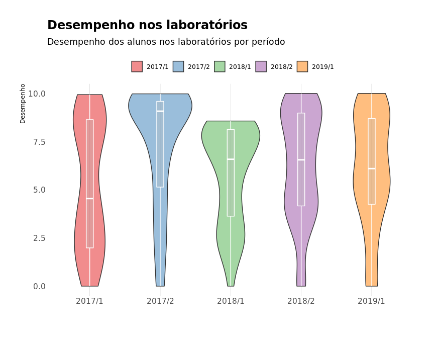

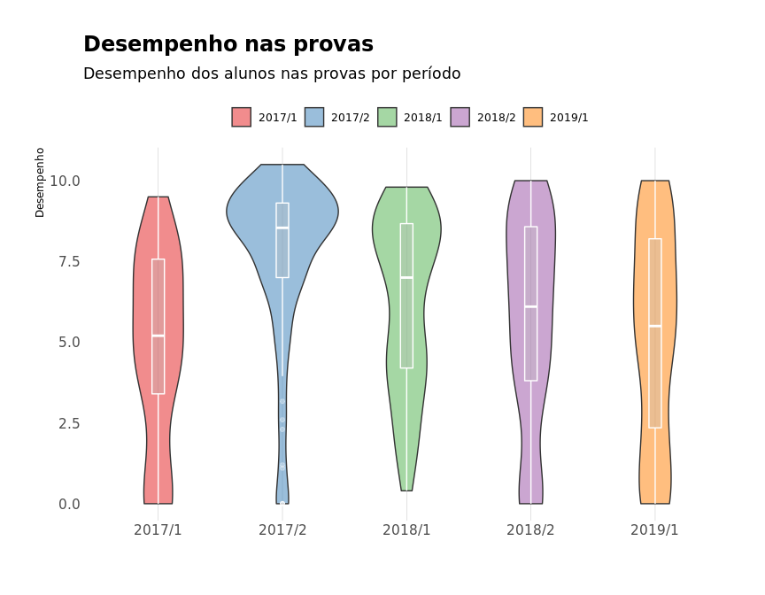

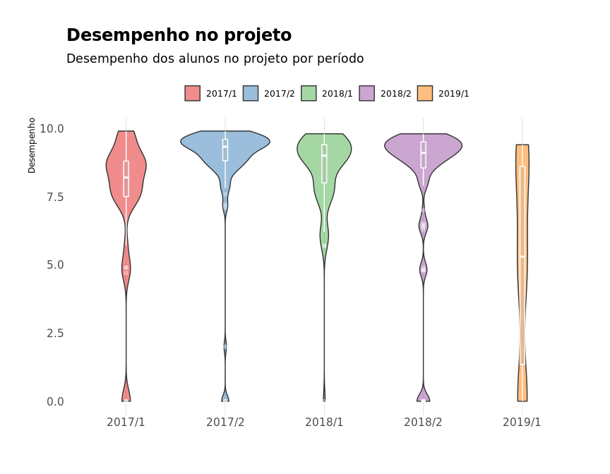

##Relações

Para investigarmos as relações entre as avaliações, primeiro vejamos o correlograma das variáveis:

###Correlograma

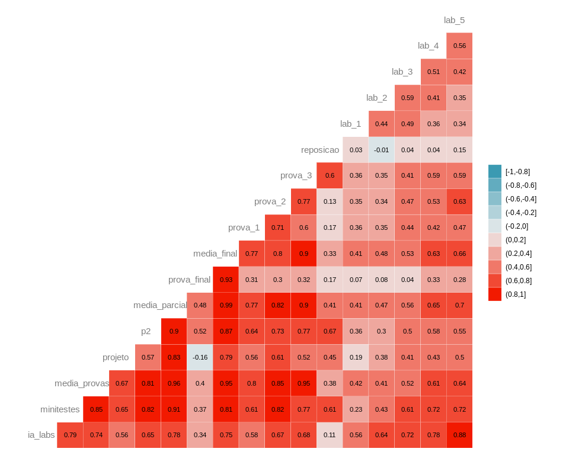

Primeiro, devemos considerar que as variáveis `media_provas`, `media_labs`, `media_parcial` e `media_final` são constituídas por outras variáveis que também estão no correlograma, portanto, não devemos levar em conta a correlação entre essas:

Constituições:

`media_provas`: `prova_1`, `prova_2`, `prova_3` e/ou `reposicao`.

`media_labs`: `lab_1`, `lab_2`, `lab_3`, `lab_4` e `lab_5`.

`media_parcial`: `media_provas`, `media_labs`, `projeto`, `p2` e `minitestes`.

`media_final`: `media_parcial` e `prova_final`.

###Se aprofundando

Tendo estudado a matriz de correlações, nos aprofundamos naquela que se mostrou a informação mais interessantes: Parece existir uma relação entre a média das provas práticas e a média das provas teóricas. Lembrando que o correlograma foi construído utilizando o método de **pearson**. Caso tivéssemos utilizado o método de **spearman** - que utiliza ranks - para encontrar a correlação entre as duas variável, encontraríamos um resultado bem semelhante:

```
# A tibble: 1 x 2
  pearson spearman
    <dbl>    <dbl>
1   0.813    0.799
```

O gráfico de dispersão:

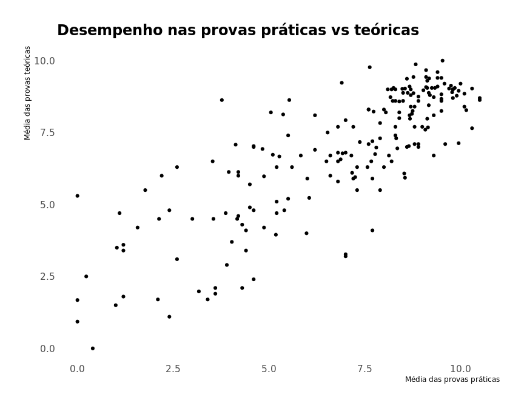

Com a linha do modelo de regressão linear simples:

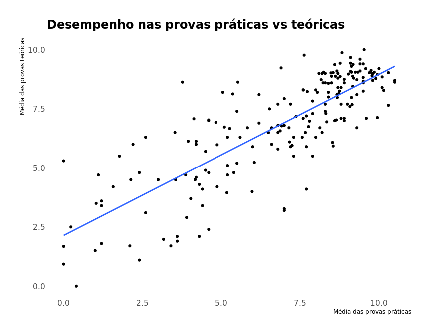

###O modelo

```
# A tibble: 2 x 5
  term        estimate std.error statistic  p.value
  <chr>          <dbl>     <dbl>     <dbl>    <dbl>
1 (Intercept)    0.257    0.353      0.728 4.68e- 1
2 p2             0.970    0.0491    19.7   7.22e-49
```

```
# A tibble: 1 x 11
  r.squared adj.r.squared sigma statistic  p.value    df logLik   AIC   BIC
      <dbl>         <dbl> <dbl>     <dbl>    <dbl> <int>  <dbl> <dbl> <dbl>
1     0.661         0.659  1.54      390. 7.22e-49     2  -372.  750.  760.
# … with 2 more variables: deviance <dbl>, df.residual <int>
```

O formato do modelo encontrado foi: **media_provas** = 0.26 + 0.97***(p2)** que explica 66% da variável resposta (R² = 0.6610089).

Vejamos, então, o que o modelo estima para cada ponto de media_provas.

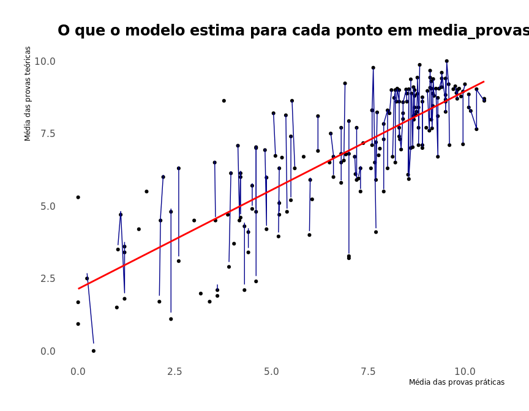

E o resíduo do modelo:

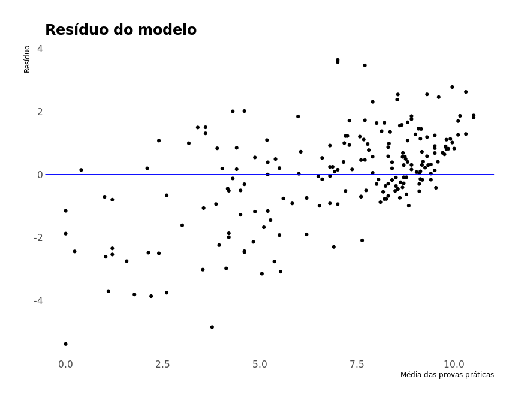

##Diferença entre avaliações

As diferenças entre as avaliação nos diz em qual avaliação o aluno teve melhor resultado e o quanto. A partir dessas diferenças, podemos identificar alunos com notas muito discrepantes e em quais atividades isso ocorre.

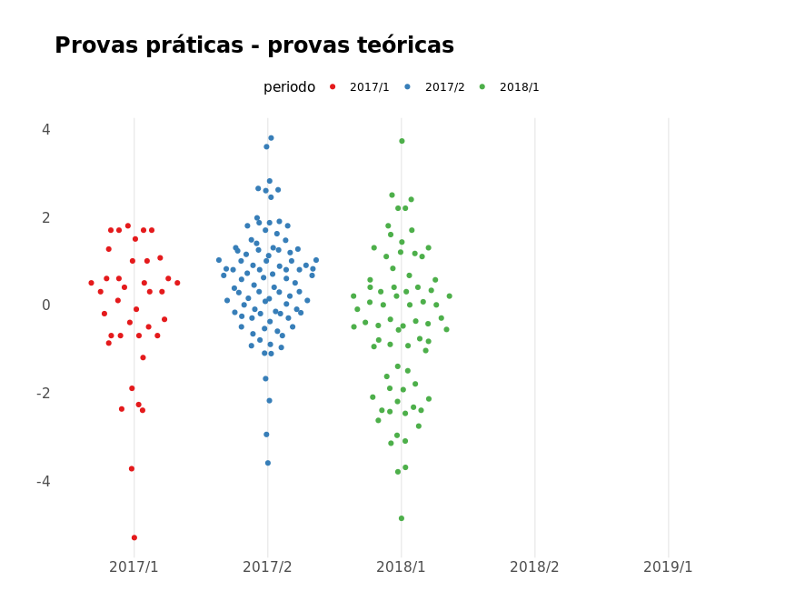

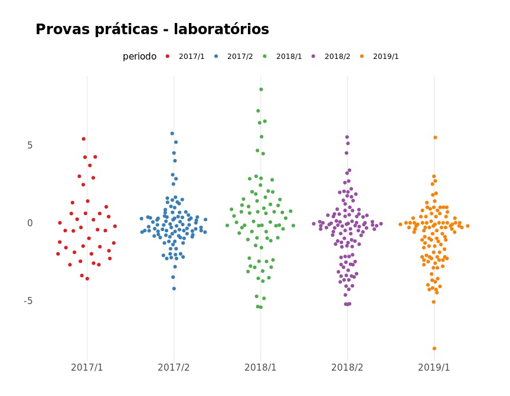

```
# A tibble: 5 x 4
  periodo desvio_padrao mediana variancia
  <chr>           <dbl>   <dbl>     <dbl>
1 2017/1           2.22  -0.470      4.93
2 2017/2           1.60  -0.225      2.55
3 2018/1           2.83   0.05       8.01
4 2018/2           2.13  -0.225      4.52
5 2019/1           1.92  -0.400      3.69
```

```
# A tibble: 1 x 2
  pearson spearman
    <dbl>    <dbl>
1   0.815    0.809
```

Medidas semelhantes e relativamente mais altas quando consideramos o panorama geral.

O gráfico de dispersão:

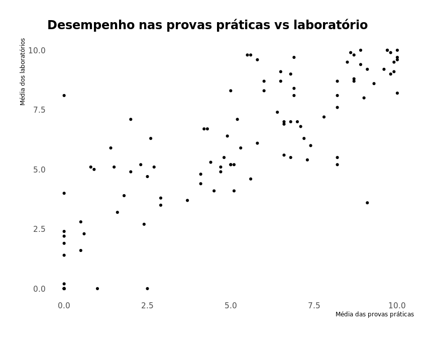

Com a linha do modelo de regressão linear simples:

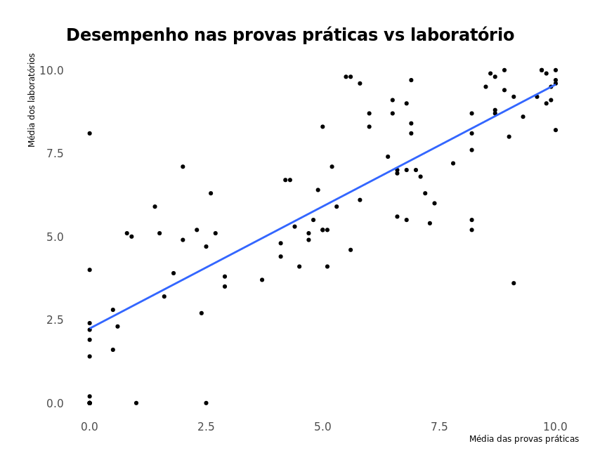

### O modelo

```
# A tibble: 2 x 5
  term        estimate std.error statistic  p.value
  <chr>          <dbl>     <dbl>     <dbl>    <dbl>
1 (Intercept)   -0.297    0.429     -0.693 4.90e- 1
2 media_labs     0.906    0.0641    14.1   1.16e-25
```

```
# A tibble: 1 x 11
  r.squared adj.r.squared sigma statistic  p.value    df logLik   AIC   BIC
      <dbl>         <dbl> <dbl>     <dbl>    <dbl> <int>  <dbl> <dbl> <dbl>
1     0.664         0.661  1.91      200. 1.16e-25     2  -212.  430.  437.
# … with 2 more variables: deviance <dbl>, df.residual <int>
```

O formato do modelo encontrado foi: **media_provas** = -0.297 + 0.9***(media_labs)** que explica 66% da variável resposta (R² = 0.664019).

O resíduo do modelo:

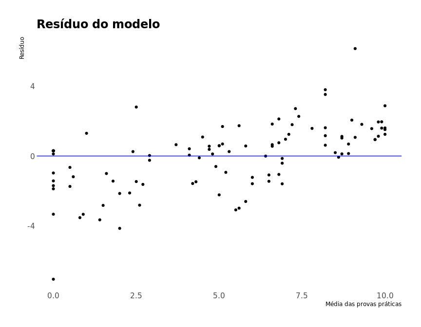

Voltando para as demais distâncias:

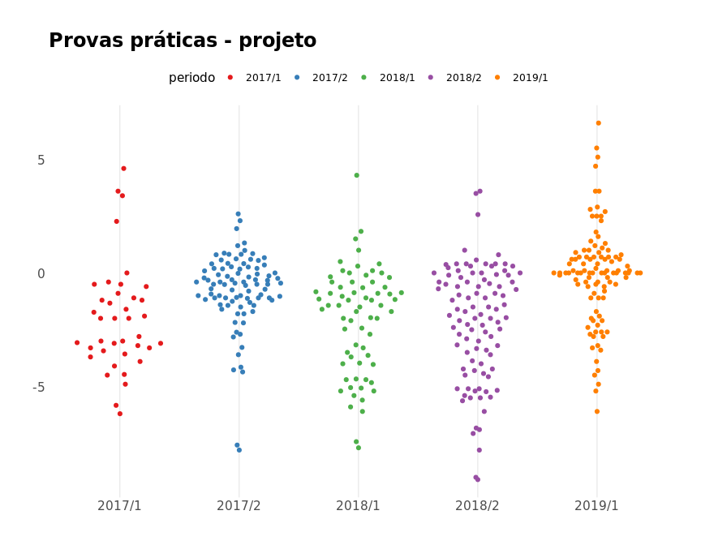

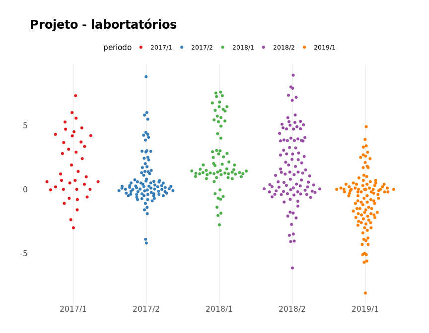

Quanto mais distante de 0, maior a diferença entre as avaliações. Podemos agora definir perfis a partir dessas diferenças.

##Agrupamento

### Between/totss

Outra medida comumente usada no kmeans é *comparar a distância (quadrática) entre o centro dos clusters e o centro dos dados com a distância (quadrática) entre os pontos todos nos dados e o centro dos dados*.

Quebrando essa ideia para ficar mais fácil de entender:

Primeiro, o *centro dos dados* é um ponto imaginário na média de todas as variáveis. É um ponto que está no meio dos dados. Em uma situação onde cada ponto é um grupo (e os grupos são os mais coesos possíveis), a soma das distâncias dos grupos para o centro dos dados é igual à soma da distância dos pontos para o centro dos dados. Generalizando: se houver estrutura de grupos e ela estiver capturada pelo agrupamento, o somatório da distância do centro de cada grupo para o centro geral dos dados será um valor alto.

Para medir para quais valores de `k` isso acontece, calculamos a *distância do centro de cada cluster para o centro dos dados* e multiplicamos pelo número de pontos nesse cluster. Somando esse valor para todos os clusters, temos `betweenss` abaixo.

Se esse valor for próximo do somatório total das distâncias dos pontos para o centro dos dados (`totss`), os pontos estão próximos do centro de seu cluster. Essa proporção pode ser usada para definir um bom valor de `k`. Quando ela para de crescer, para de valer à pena aumentar `k`.

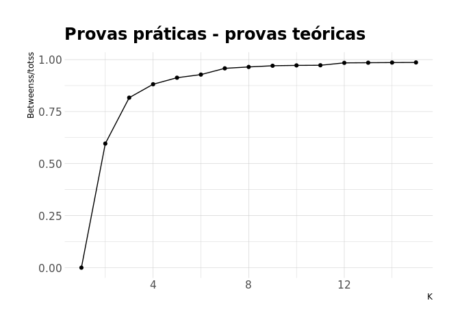

O bom valor de k parece ser 3, que vai ser o número de clusters para o nosso algoritmo de agrupamento.

###K-means

O algoritmo nos da a seguinte distribuição para os grupos:

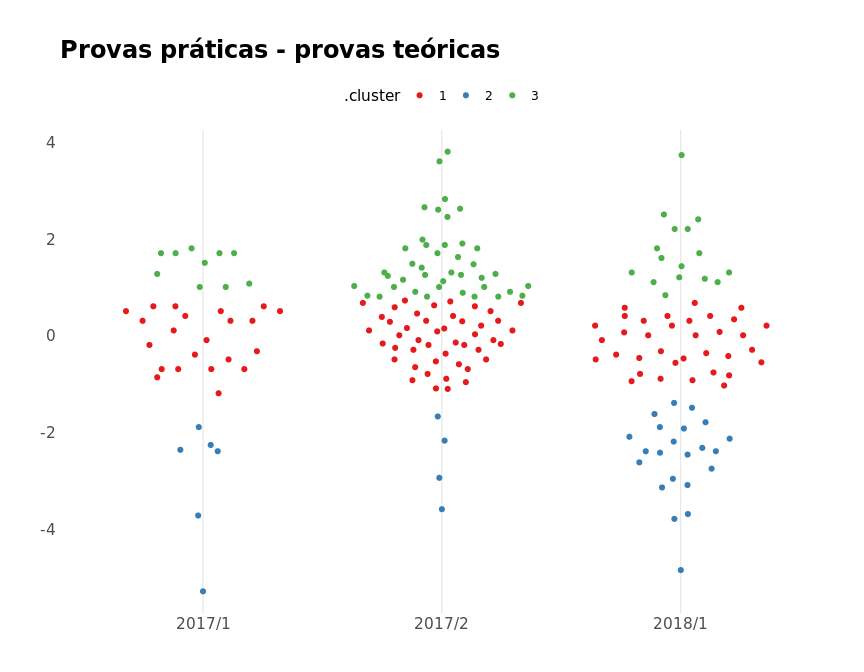

Algumas medidas para os grupos:

```
# A tibble: 3 x 4
  .cluster desvio_padrao mediana variancia
  <fct>            <dbl>   <dbl>     <dbl>
1 1                0.523 -0.1000     0.274
2 2                0.913 -2.4        0.834
3 3                0.702  1.30       0.493
```

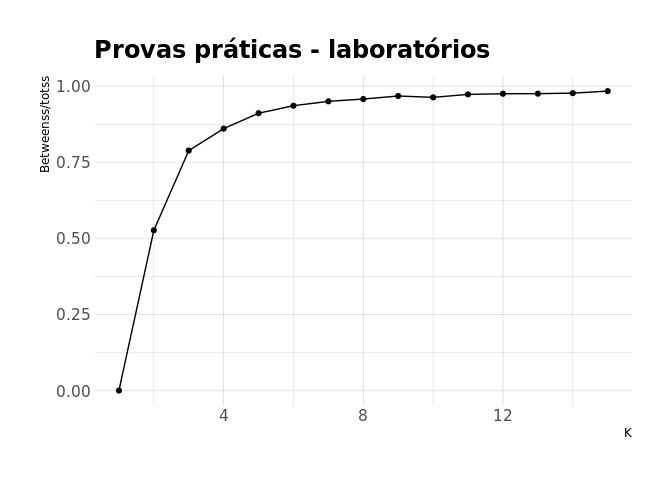

O bom valor de k parece ser 4, que vai ser o número de clusters para o nosso algoritmo de agrupamento.

O algoritmo nos da a seguinte distribuição para os grupos:

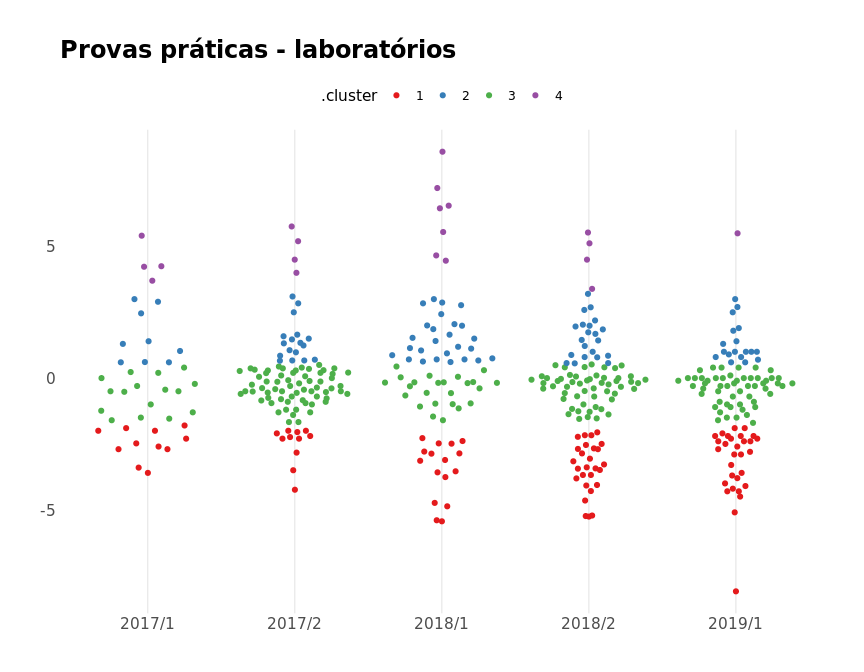

Algumas medidas para os grupos:

```
# A tibble: 4 x 4
  .cluster desvio_padrao mediana variancia
  <fct>            <dbl>   <dbl>     <dbl>
1 1                1.08    -2.83     1.18
2 2                0.772    1.30     0.596
3 3                0.570   -0.3      0.325
4 4                1.26     5.16     1.60
```

O grupo 1 possui uma mediana de -2.83, uma diferença de quase 3 pontos da media das provas práticas para a media dos laboratórios.

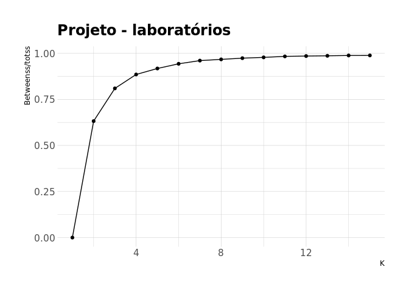

O bom valor de k parece ser 4, que vai ser o número de clusters para o nosso algoritmo de agrupamento.

O algoritmo nos da a seguinte distribuição para os grupos:

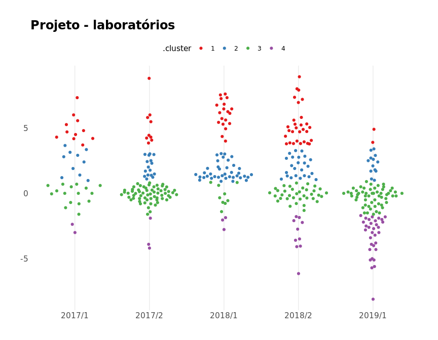

Algumas medidas para os grupos:

```
# A tibble: 4 x 4
  .cluster desvio_padrao mediana variancia
  <fct>            <dbl>   <dbl>     <dbl>
1 1                1.33   5.16       1.77
2 2                0.747  1.79       0.559
3 3                0.581 -0.0400     0.337
4 4                1.38  -2.76       1.90
```

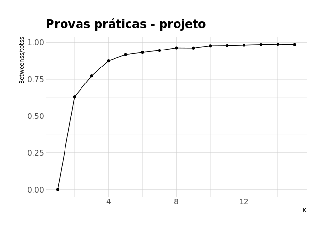

O bom valor de k parece ser 4, que vai ser o número de clusters para o nosso algoritmo de agrupamento.

O algoritmo nos da a seguinte distribuição para os grupos:

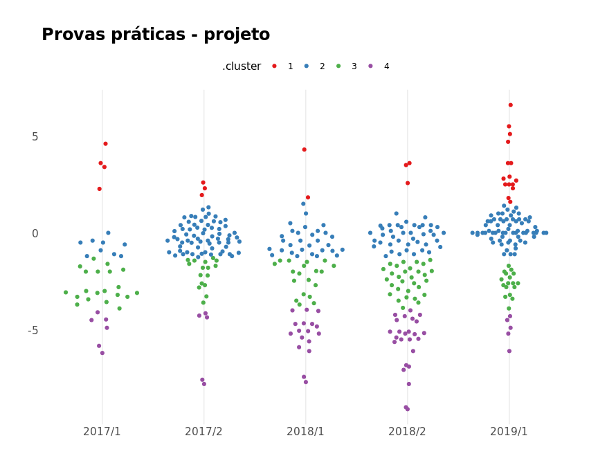

Algumas medidas para os grupos:

```
# A tibble: 4 x 4
  .cluster desvio_padrao mediana variancia
  <fct>            <dbl>   <dbl>     <dbl>
1 1                1.24   2.8        1.53
2 2                0.659 -0.0900     0.434
3 3                0.742 -2.4        0.550
4 4                1.25  -5.14       1.56
```

##Evolução dos grupos 2018.2

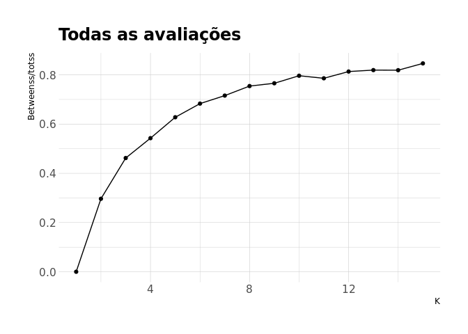

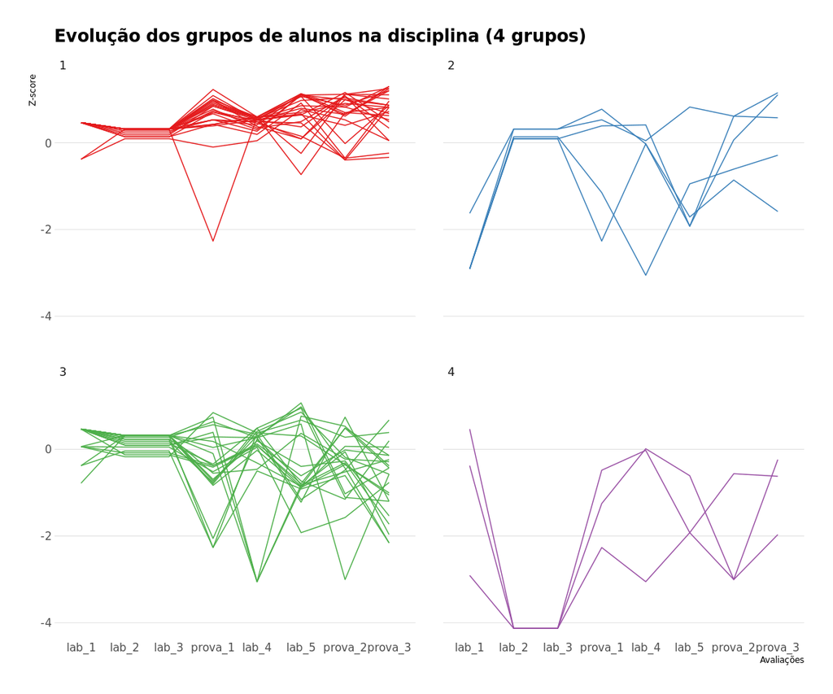

O bom valor de k parece ser 4, que vai ser o número de clusters para o nosso algoritmo de agrupamento.

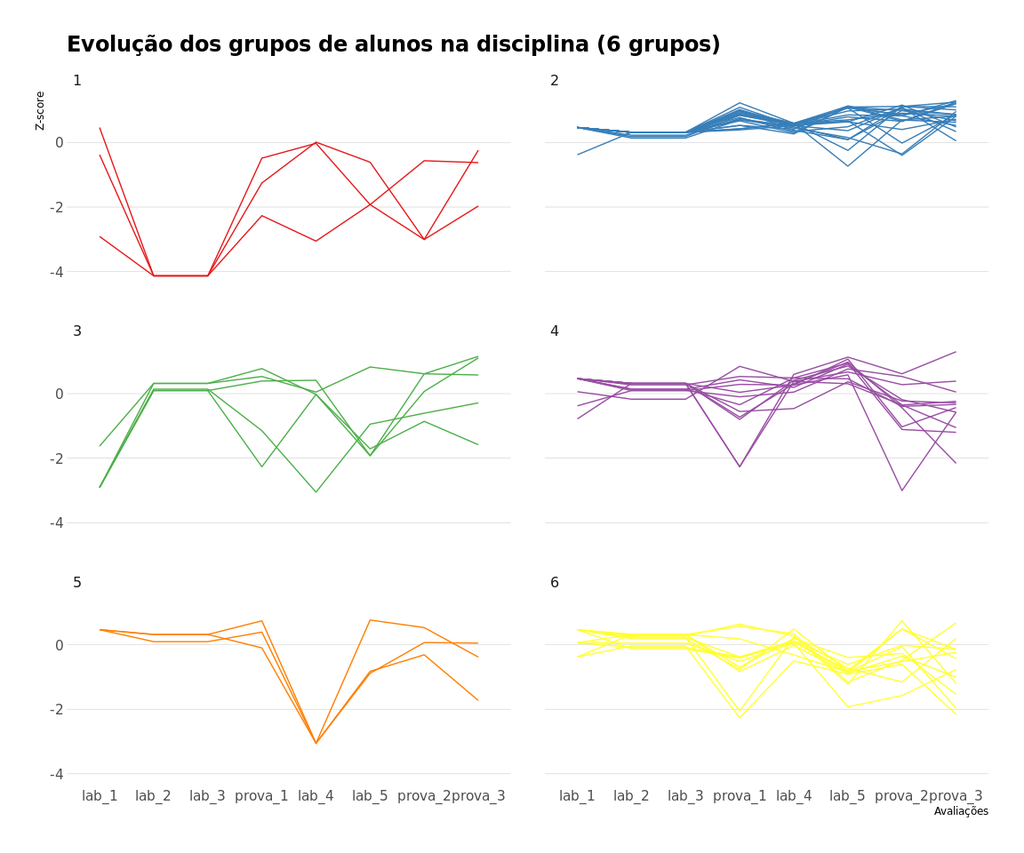

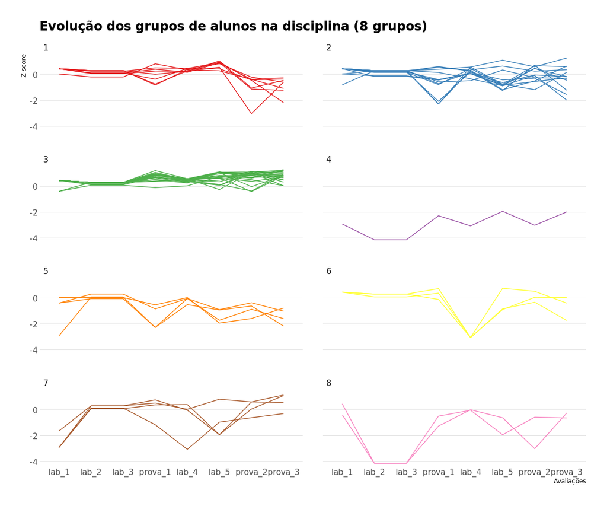